# Bibliometria - Heat shock proteins in plants stressed by cold

Ramir Bavaresco Junior

4/30/2019

## Estresse abiótico

As plantas são constantemente expostas às adversidades ambientais e precisam ser capazes de interpretar e responder rapidamente a esses fatores. Estresses abióticos como seca, salinidade metais pesados, temperatura elevada e frio resultam no rompimento da homeostasia de proteínas. Sob condições de estresse, múltiplas proteínas celulares podem se envolver de forma imprecisa, porém as *Heat shock proteins* - HSPs, protegem essas proteínas contra a agregação e auxiliam o correto enovelamento. Entretanto, se escaparem deste processo serão eventualmente eliminadas pelo sistema proteolítico. (Saibil, 2013; Martin et al., 1993).

As HSPs são codificadas por uma família gênica complexa em plantas. Elas funcionam como chaperonas, sendo responsáveis pelo dobramento, montagem, translocação e degradação de proteínas sob condições de estresse e em processos normais (Park & Seo, 2015).

Inicialmente, as HSPs foram descritas por serem induzidas sob temperaturas elevadas (Ritosa, 1962), contudo atualmente sabe-se que a expressão de genes *HSPs* estão relacionados a ampla variedade de estresses, incluindo o frio, luz violeta ou estresse biótico (Vierling, 1991; Boston, Viitanen & Vierling, 1996).

Nas plantas, as famílias de proteínas de choque térmico são divididas em cinco subfamílias com base no peso molecular de cada membro: HSP100, HSP90, HSP70, HSP60 e sHSPs. Proteínas da subfamília HSP100 são responsáveis por manter a integridade funcional de polipeptídeos chave, permitindo a sinalização de agregados proteícos não funcionais, além de degradar peptídeos irreversivelmente danificados (Gupta et al., 2010; Kim, Hwang & Lee, 2007); em plantas, as proteínas HSP100 são amplamente estudadas por seu papel na tolerância ao calor (Lin et al., 2014).

As proteínas da subfamília HSP90 são induzidas rapidamente por diversas condições de estresse e se associam a várias proteínas intracelulares, incluindo calmodulina, actina, tubulina, quinases e proteínas receptoras (Gupta et al., 2010); Liu e colaboradores (2004) caracterizaram HSP90 como reguladora chave no crescimento e desenvolvimento normal em *Arabidopsis thaliana* e *Nicotiana benthamiana*.

Já dentre as subfamílias de HSPs, a subfamília HSP70 possui os domínios mais conservados. Os membros desta família estão presentes no citosol, retículo endoplasmático, mitocôndria e cloroplasto (Hafrén et al., 2010; Ray et al., 2016). Em seringueiras Zhang e colaboradores (2009) induziram a expressão de um gene da subfamília *HSP70* sob condição de estresse abiótico (frio e calor) e verificaram que o mesmo tem ação de proteção contra calor e frio. Mantello e colaboradores (2018) verificaram a expressão de HSP70 em ensaios de termotolerância para *Hevea brasiliensis*.

As proteínas da subfamília HSP60 são encontradas em bactérias, mitocôndrias e cloroplasto e desempenham papel importante no auxílio às proteínas plastidiais, como Rubisco (Ribulose-1,5-bifosfato carboxilase/oxigenase), além de contribuir para o dobramento de proteínas transportadas para o cloroplasto e mitocôndrias (Wang et al., 2004).

Os membros da subfamília sHSPs foram um grupo muito importante, composto por proteínas diversas e estão presentes em todos os organismos, indicando que essas proteínas evoluíram cedo na história da vida. Algumas plantas apresentam mais de 30 sHSPs, sendo a maioria regulada em respostas ao calor (Santhanagopalan et al., 2015). Song e Ahn (2010) verificaram que a expressão de HSP17.7 em cenoura, por exemplo, conferiu tolerância a estresse de alta e baixa temperatura.

O presente relatório tem por objetivo fazer uma análise bibliométrica de artigos de proteínas de choque térmico em plantas sob estresse de frio.

## Pacote bibliometrix

O pacote bibliometrix fornece um conjunto de ferramentas para pesquisas quantitativas em bibliometria e cientometria. A bibliometria tornou-se a principal ferramenta para análises quantitativas na ciência. Essencialmente, bibliometria é uma aplicação de análises quantitativas e estatística para dados de publicações e citações. A bibliometria também é usada em avaliação de performance de pesquisas, especialmente em Universidades, instituições governamentais, laboratórios e também por tomadores de decisão, diretores de pesquisa, administradores, especialistas em informação e bibliotecários.

O comando abaixo foi utilizado para instalar instalar o pacote bibliometrix com todas as dependências.

```r
options(width = 60)
install.packages("bibliometrix", dependencies=TRUE, repos = "http://cran.us.r-project.org")
```

```
##
##   There is a binary version available but the source
##   version is later:
##              binary source needs_compilation
## bibliometrix  2.1.2  2.2.0             FALSE
```

```
## installing the source package 'bibliometrix'
```

Essa análise bibliométrica foi realizada com base nas informações disponíveis no site https://cran.r-project.org/web/packages/bibliometrix/vignettes/bibliometrix-vignette.html.

Após a instalação do pacote com todas as dependências, o mesmo foi carregado utilizando o seguinte comando:

```r
options(width = 60)
library(bibliometrix)
```

## Importando os dados para o R

O arquivo no formato BibTeX foi carregado em um objeto do tipo vetor de caracteres com o comando:

```r
options(width = 60)
D <- readFiles("data/hsp_plant_stress_cold.bib")
```

Este objeto *D* do tipo vetor de caracteres precisa ser convertido em um objeto do tipo dataframe, isso foi realizado com o comando:

```r
options(width = 60)
M <- convert2df(D, dbsource = "isi", format = "bibtex")
```

```
##
## Converting your isi collection into a bibliographic dataframe
##
## Articles extracted   100
## Articles extracted   200
## Articles extracted   300
## Articles extracted   374
## Done!
##
##
## Generating affiliation field tag AU_UN from C1:  Done!
```

O objeto *results* recebe a função *biblioAnalysis* que serve para calcular as principais medidas bibliométricas deste dataset.

```r
options(width = 60)
results <- biblioAnalysis(M, sep = ";")
```

A função *summary* serve para resumir as principais informações do dataset.

```r
options(width = 60)
options(width=100)
S <- summary(object = results, k = 10, pause = FALSE)
```

```
##
##
## Main Information about data
##
##  Documents                             374
##  Sources (Journals, Books, etc.)       148
##  Keywords Plus (ID)                    1368
##  Author's Keywords (DE)                959
##  Period                                1991 - 2018
##  Average citations per documents       47.92
##
##  Authors                               1534
##  Author Appearances                    1924
##  Authors of single-authored documents  9
##  Authors of multi-authored documents   1525
##  Single-authored documents             10
##
##  Documents per Author                  0.244
##  Authors per Document                  4.1
##  Co-Authors per Documents              5.14
##  Collaboration Index                   4.19
##
##  Document types
##  ARTICLE                         330
##  ARTICLE, PROCEEDINGS PAPER      5
##  NOTE                            1
##  REVIEW                          37
##
##
## Annual Scientific Production
##
##  Year    Articles
##     1991        2
##     1992        2
##     1993        6
##     1994        8
##     1995        4
##     1996        7
##     1997        5
##     1998        9
```

[output cut: 102 more lines]

```
##
##
## Most Relevant Keywords
##
##    Author Keywords (DE)      Articles Keywords-Plus (ID)     Articles
## 1        HEAT STRESS               38   PLANTS                     98
## 2        ABIOTIC STRESS            37   ARABIDOPSIS THALIANA       97
## 3        GENE EXPRESSION           26   HEAT SHOCK PROTEINS        94
## 4        COLD STRESS               25   GENE EXPRESSION            71
## 5        HEAT SHOCK PROTEIN        20   EXPRESSION                 65
## 6        HEAT SHOCK PROTEINS       18   COLD ACCLIMATION           59
## 7        PROTEOMICS                18   ARABIDOPSIS                49
## 8        HEAT SHOCK                17   TOLERANCE                  47
## 9        COLD ACCLIMATION          15   FREEZING TOLERANCE         43
## 10       ARABIDOPSIS               14   ABSCISIC ACID              41
```

A função *plot* serve para calcular as principais informações do dataset.

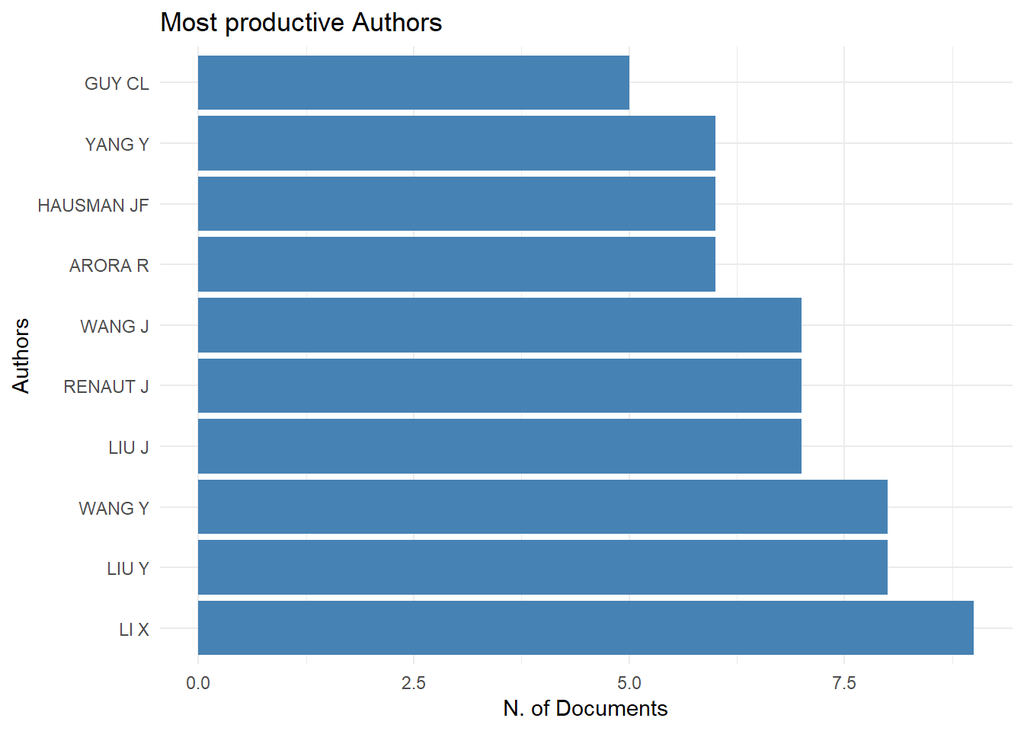

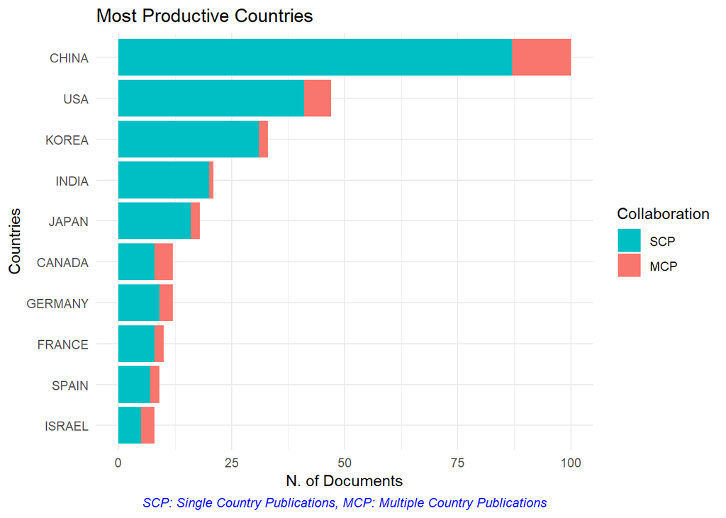

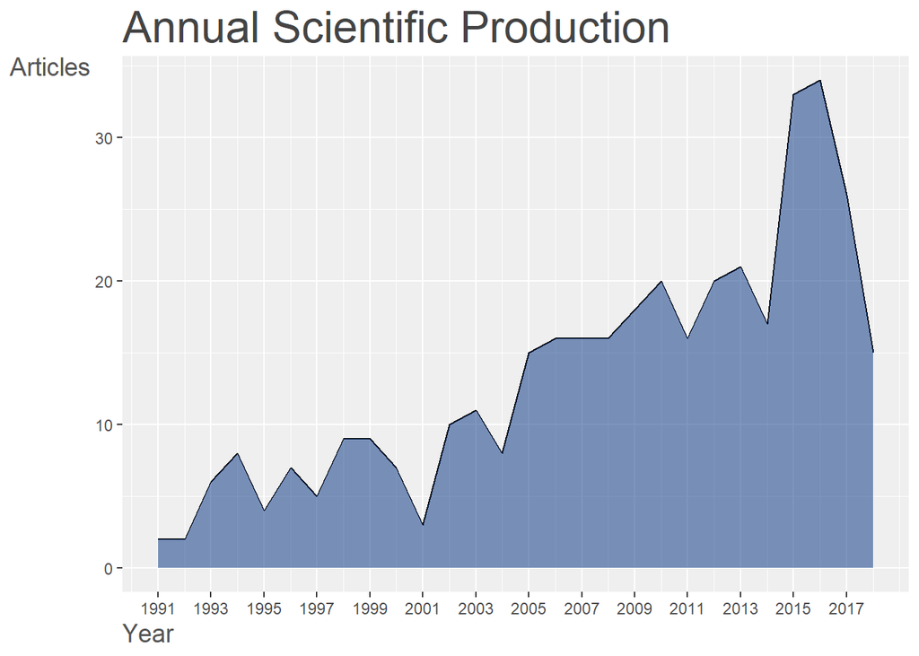

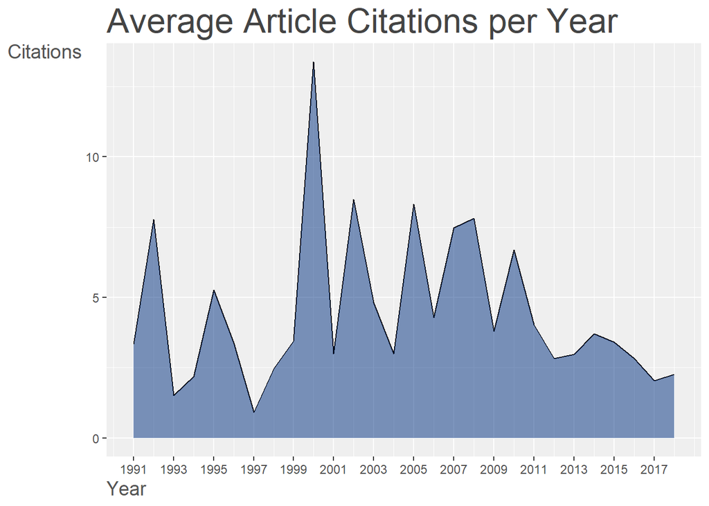

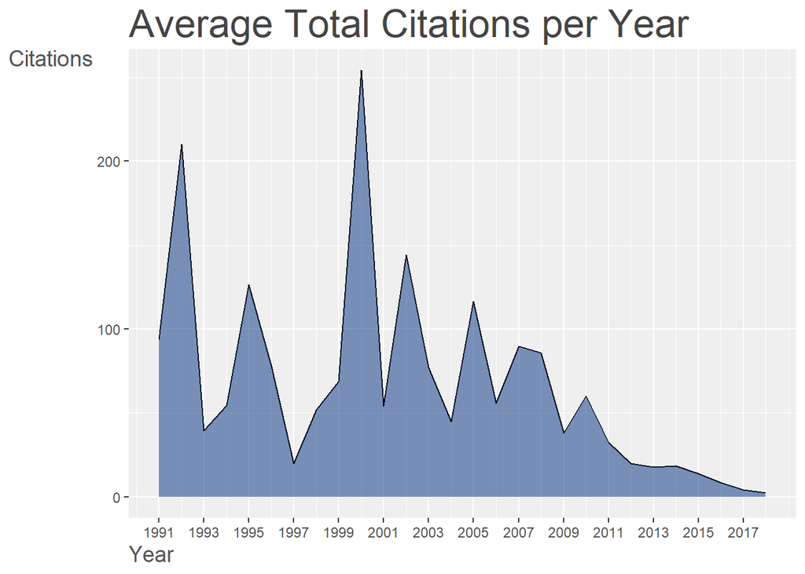

```r
options(width = 60)
plot(x = results, k = 10, pause = FALSE)
```

A estrutura dos dados pode ser verificada com o comando abaixo a fim de verificar como os artigos estão separados, seja por ponto vírgula ou ponto duplo espaço.

```r
options(width = 60)
M$CR[1]
```

```
## [1] "AHN YJ, 2006, PLANT CELL ENVIRON, V29, P95, DOI 10.1111/J.1365-3040.2005.01403.X.;AHUJA I, 2010, TRENDS PLANT SCI, V15, P664, DOI 10.1016/J.TPLANTS.2010.08.002.;AL-WHAIBI MOHAMED H., 2011, JOURNAL OF KING SAUD UNIVERSITY SCIENCE, V23, P139, DOI 10.1016/J.JKSUS.2010.06.022.;BATES LS, 1973, PL…
```

Os manuscritos mais citados podem ser verificados com o comando abaixo:

```r
options(width = 60)
CR <- citations(M, field = "article", sep = ";")
cbind(CR$Cited[1:10])
```

```
##                                                                                            [,1]
## VIERLING E, 1991, ANNU REV PLANT PHYS, V42, P579, DOI 10.1146/ANNUREV.PP.42.060191.003051.   71
## WANG WX, 2004, TRENDS PLANT SCI, V9, P244, DOI 10.1016/J.TPLANTS.2004.03.006.                71
## LIVAK KJ, 2001, METHODS, V25, P402, DOI 10.1006/METH.2001.1262.                              41
## BRADFORD MM, 1976, ANAL BIOCHEM, V72, P248, DOI 10.1016/0003-2697(76)90527-3.                35
## LAEMMLI UK, 1970, NATURE, V227, P680, DOI 10.1038/227680A0.                                  35
## THOMASHOW MF, 1999, ANNU REV PLANT PHYS, V50, P571, DOI 10.1146/ANNUREV.ARPLANT.50.1.571.    32
## SUN WN, 2002, BBA-GENE STRUCT EXPR, V1577, P1, DOI 10.1016/S0167-4781(02)00417-7.            31
## WANG WX, 2003, PLANTA, V218, P1, DOI 10.1007/S00425-003-1105-5.                              29
## SABEHAT A, 1998, PLANT PHYSIOL, V117, P651, DOI 10.1104/PP.117.2.651.                        28
## WATERS ER, 1996, J EXP BOT, V47, P325, DOI 10.1093/JXB/47.3.325.                             28
```

Os manuscritos cujo o primeiro autor é mais citado:

```r
options(width = 60)
CR <- citations(M, field = "author", sep = ";")
cbind(CR$Cited[1:10])
```

```
##              [,1]
## WANG WX       104
## VIERLING E     84
## GUY CL         65
## SABEHAT A      65
## MITTLER R      63
## SUNG DY        59
## THOMASHOW MF   58
## SHINOZAKI K    56
## KOTAK S        55
## SEKI M         55
```

Autores locais mais citados:

```r
options(width = 60)
CR <- localCitations(M, sep = ";")
```

```
## Articles analysed   100
## Articles analysed   200
## Articles analysed   300
## Articles analysed   357
```

```r
CR$Authors[1:10,]
```

|  | Author | LocalCitations |
| --- | --- | --- |
| 405 | GUY CL | 50 |
| 705 | LI QB | 32 |
| 424 | HASKELL DW | 29 |
| 425 | HAUSMAN JF | 28 |
| 765 | LURIE S | 28 |
| 982 | RENAUT J | 27 |
| 485 | HUEBNER M | 24 |
| 632 | KRISHNA P | 24 |
| 1136 | SWINDELL WR | 24 |
| 1265 | WEBER AP | 24 |

```r
CR$Papers[1:10,]
```

|  | Paper | DOI | Year | LCS | GCS |
| --- | --- | --- | --- | --- | --- |
| 130 | SWINDELL WR, 2007, BMC GENOMICS | 10.1186/1471-2164-8-125 | 2007 | 24 | 234 |
| 20 | KRISHNA P, 1995, PLANT PHYSIOL | 10.1104/PP.107.3.915 | 1995 | 23 | 99 |
| 15 | ANDERSON JV, 1994, PLANT PHYSIOL | 10.1104/PP.104.4.1359 | 1994 | 20 | 132 |
| 81 | SUNG DY, 2003, TRENDS PLANT SCI | 10.1016/S1360-1385(03)00047-5 | 2003 | 17 | 300 |
| 141 | TIMPERIO AM, 2008, J PROTEOMICS | 10.1016/J.JPROT.2008.07.005 | 2008 | 16 | 240 |
| 63 | RIZHSKY L, 2002, PLANT PHYSIOL | 10.1104/PP.006858 | 2002 | 15 | 509 |
| 152 | SCHRAMM F, 2008, PLANT J | 10.1111/J.1365-313X.2007.03334.X | 2008 | 14 | 190 |
| 37 | SABEHAT A, 1998, PHYSIOL PLANT | 10.1034/J.1399-3054.1998.1030317.X | 1998 | 13 | 85 |
| 89 | LOPEZ-MATAS MA, 2004, PLANT PHYSIOL | 10.1104/PP.103.035857 | 2004 | 13 | 48 |
| 28 | WISNIEWSKI M, 1996, PHYSIOL PLANT | NA | 1996 | 12 | 89 |

Ranking de dominância de autores:

```r
options(width = 60)
DF <- dominance(results, k = 10)
DF
```

|  | Author | Dominance Factor | Tot Articles | Single-Authored | Multi-Authored | First-Authored | Rank by Articles | Rank by DF |
| --- | --- | --- | --- | --- | --- | --- | --- | --- |
| 1 | RENAUT J | 0.4285714 | 7 | 0 | 7 | 3 | 7 | 1 |
| 2 | WANG J | 0.4285714 | 7 | 0 | 7 | 3 | 7 | 1 |
| 3 | WANG X | 0.4000000 | 5 | 0 | 5 | 2 | 1 | 3 |
| 4 | YANG Y | 0.3333333 | 6 | 0 | 6 | 2 | 5 | 4 |
| 5 | LIU Y | 0.2500000 | 8 | 0 | 8 | 2 | 9 | 5 |
| 6 | VOINIKOV VK | 0.2000000 | 5 | 0 | 5 | 1 | 1 | 6 |
| 7 | ZHANG H | 0.2000000 | 5 | 0 | 5 | 1 | 1 | 6 |
| 8 | ZHANG X | 0.2000000 | 5 | 0 | 5 | 1 | 1 | 6 |
| 9 | ARORA R | 0.1666667 | 6 | 0 | 6 | 1 | 5 | 9 |
| 10 | WANG Y | 0.1250000 | 8 | 0 | 8 | 1 | 9 | 10 |

H-Index dos autores

```r
options(width = 60)
indices <- Hindex(M, field = "author", elements="RENAUT J", sep = ";", years = 10)
```

Indice de impacto do autor Renaut J (escolhido por sero primeiro da lista)

```r
options(width = 60)
indices$H
```

| Author | h_index | g_index | m_index | TC | NP | PY_start |
| --- | --- | --- | --- | --- | --- | --- |
| RENAUT J | 3 | 3 | 0.4285714 | 50 | 3 | 2013 |

Citações do autor Renaut:

```r
options(width = 60)
indices$CitationList
```

```
## [[1]]
##                          Authors
## 3 CHEN K;RENAUT J;SERGEANT K;WEI
## 1 SERGEANT K;KIEFFER P;DOMMES J;
## 2 FOLGADO R;SERGEANT K;RENAUT J;
##                          Journal Year TotalCitation
## 3     PLANT CELL AND ENVIRONMENT 2013            13
## 1 ENVIRONMENTAL AND EXPERIMENTAL 2014            17
## 2          JOURNAL OF PROTEOMICS 2014            20
```

H-Index dos 10 autores mais produtivos

```r
options(width = 60)
authors=gsub(","," ",names(results$Authors)[1:10])
indices <- Hindex(M, field = "author", elements=authors, sep = ";", years = 50)
indices$H
```

| Author | h_index | g_index | m_index | TC | NP | PY_start |
| --- | --- | --- | --- | --- | --- | --- |
| LI X | 7 | 8 | 0.6363636 | 78 | 9 | 2009 |
| LIU Y | 7 | 10 | 0.4375000 | 109 | 10 | 2004 |
| WANG Y | 8 | 13 | 0.6666667 | 225 | 13 | 2008 |
| LIU J | 5 | 7 | 0.3571429 | 64 | 7 | 2006 |
| RENAUT J | 7 | 7 | 0.4375000 | 368 | 7 | 2004 |
| WANG J | 5 | 9 | 0.3571429 | 118 | 9 | 2006 |
| ARORA R | 6 | 6 | 0.2500000 | 284 | 6 | 1996 |
| HAUSMAN JF | 6 | 6 | 0.3750000 | 1020 | 6 | 2004 |
| YANG Y | 4 | 4 | 0.3333333 | 138 | 4 | 2008 |
| GUY CL | 5 | 5 | 0.1923077 | 557 | 5 | 1994 |

Top autores mais produtivos ao longo do tempo

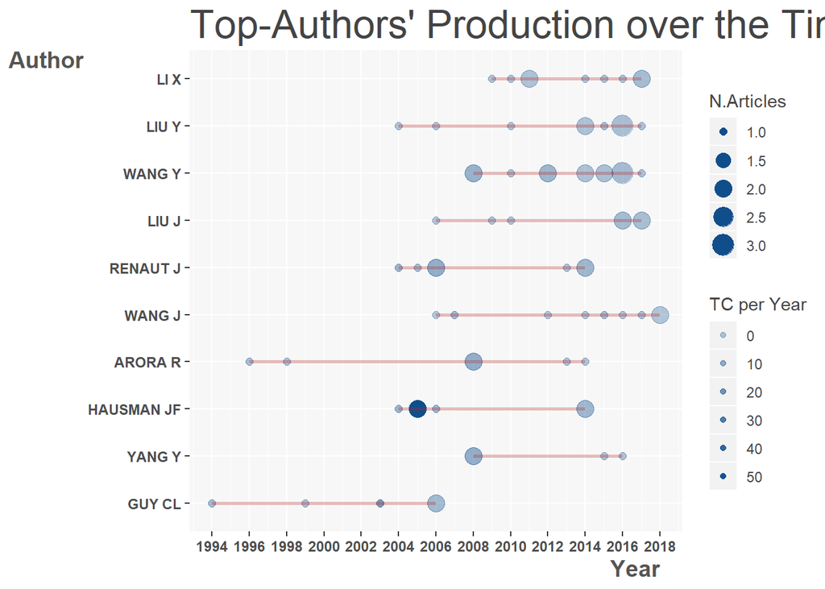

```r
options(width = 60)
topAU <- authorProdOverTime(M, k = 10, graph = TRUE)
```

Autores mais produtivos por ano (Tabela)

```r
options(width = 60)
head(topAU$dfAU)
```

|  | Author | year | freq | TC | TCpY |
| --- | --- | --- | --- | --- | --- |
| 1 | ARORA R | 1996 | 1 | 89 | 3.708333 |
| 2 | ARORA R | 1998 | 1 | 51 | 2.318182 |
| 3 | ARORA R | 2008 | 2 | 123 | 10.250000 |
| 4 | ARORA R | 2013 | 1 | 13 | 1.857143 |
| 5 | ARORA R | 2014 | 1 | 8 | 1.333333 |
| 6 | GUY CL | 1994 | 1 | 132 | 5.076923 |

Lista de documentos dos autores

```r
options(width = 60)
head(topAU$dfPapersAU)
```

|  | Author | year | TI | SO | DOI | TC | TCpY |
| --- | --- | --- | --- | --- | --- | --- | --- |
| 2 | LI X | 2017 | HETEROLOGOUS EXPRESSION OF THREE CAMELLIA SINENSIS SMALL HEAT SHOCK PROTEIN GENES CONFERS TEMPERATURE STRESS TOLERANCE IN YEAST AND ARABIDOPSIS THALIANA | PLANT CELL REPORTS | 10.1007/S00299-017-2143-Y | 5 | 1.666667 |
| 3 | LI X | 2017 | SUMO E3 LIGASES GMSIZ1A AND GMSIZ1B REGULATE VEGETATIVE GROWTH IN SOYBEAN | JOURNAL OF INTEGRATIVE PLANT BIOLOGY | 10.1111/JIPB.12504 | 7 | 2.333333 |
| 4 | LI X | 2016 | A NOVEL AP2/ERF TRANSCRIPTION FACTOR FROM STIPA PURPUREA LEADS TO ENHANCED DROUGHT TOLERANCE IN ARABIDOPSIS THALIANA | PLANT CELL REPORTS | 10.1007/S00299-016-2030-Y | 8 | 2.000000 |
| 5 | LI X | 2015 | PHYSIOLOGICAL AND PROTEOMIC ADAPTATION OF THE ALPINE GRASS STIPA PURPUREA TO A DROUGHT GRADIENT | PLOS ONE | 10.1371/JOURNAL.PONE.0117475 | 7 | 1.400000 |
| 6 | LI X | 2014 | IDENTIFICATION OF DIFFERENTIALLY EXPRESSED GENES IN LEAF OF REAUMURIA SOONGORICA UNDER PEG-INDUCED DROUGHT STRESS BY DIGITAL GENE EXPRESSION PROFILING | PLOS ONE | 10.1371/JOURNAL.PONE.0094277 | 9 | 1.500000 |
| 7 | LI X | 2011 | SMALL HEAT SHOCK PROTEIN LIMHSP16.45 PROTECTS POLLEN MOTHER CELLS AND TAPETAL CELLS AGAINST EXTREME TEMPERATURES DURING LATE ZYGOTENE TO PACHYTENE STAGES OF MEIOTIC PROPHASE I IN DAVID LILY | PLANT CELL REPORTS | 10.1007/S00299-011-1106-Y | 13 | 1.444444 |

Coeficiente de estimação da Lei de Lotka

```r
options(width = 60)
L <- lotka(results)
```

Produtividade dos autores. Distribuição empírica

```r
options(width = 60)
L$AuthorProd
```

| N.Articles | N.Authors | Freq |
| --- | --- | --- |
| 1 | 1279 | 0.8337679270 |
| 2 | 179 | 0.1166883963 |
| 3 | 51 | 0.0332464146 |
| 4 | 10 | 0.0065189048 |
| 5 | 6 | 0.0039113429 |
| 6 | 3 | 0.0019556714 |
| 7 | 3 | 0.0019556714 |
| 8 | 2 | 0.0013037810 |
| 9 | 1 | 0.0006518905 |

Estimativa do coefficiente Beta

```r
options(width = 60)
L$Beta
```

```
## [1] 3.272489
```

Constante

```r
options(width = 60)
L$C
```

```
## [1] 0.9079488
```

Qualidade do ajuste

```r
options(width = 60)
L$R2
```

```
## [1] 0.988239
```

P-value de Kolmogorov-Smirnoff para o teste de duas amostras

```r
options(width = 60)
L$p.value
```

```
## [1] 0.03663105
```

Distribuição observada

```r
options(width = 60)
Observed=L$AuthorProd[,3]
```

Distribuição teórica com Beta = 2

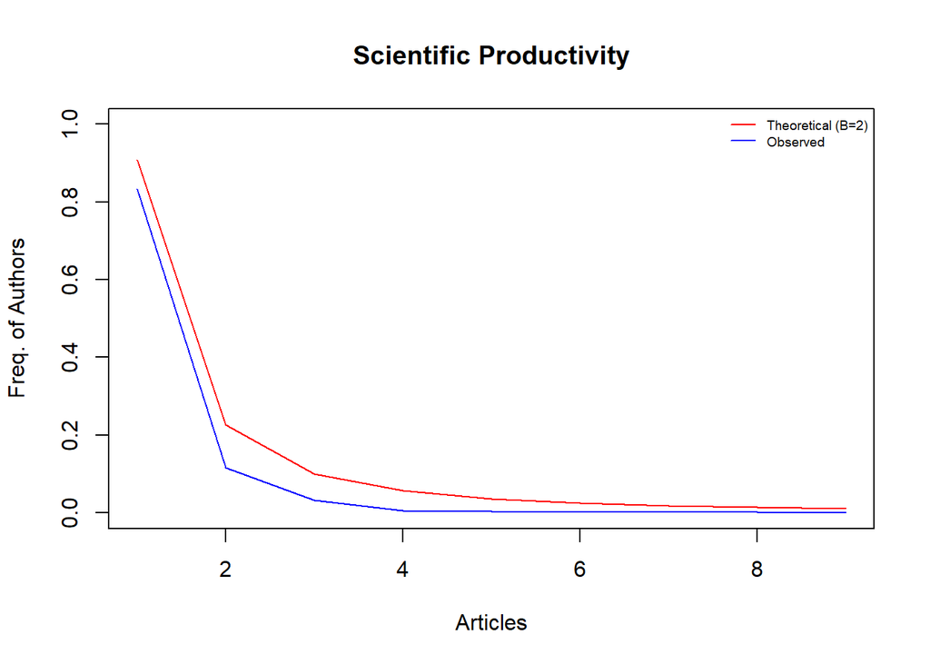

```r
options(width = 60)
Theoretical=10^(log10(L$C)-2*log10(L$AuthorProd[,1]))
options(width = 60)
plot(L$AuthorProd[,1],Theoretical,type="l",col="red", ylim=c(0, 1), xlab="Articles",ylab="Freq. of Authors", main="Scientific Productivity")
lines(L$AuthorProd[,1],Observed,col="blue")
legend(x="topright",c("Theoretical (B=2)","Observed"), col=c("red","blue"),
       lty = c(1,1,1),cex=0.6,bty="n")
```

Matrizes de redes bibliográficas Redes bipartidas

```r
options(width = 60)
A <- cocMatrix(M, Field = "SO", sep = ";")
```

Ordem decrescente

```r
options(width = 60)
sort(Matrix::colSums(A), decreasing = TRUE)[1:5]
```

```
##       PHYSIOLOGIA PLANTARUM            PLANT PHYSIOLOGY
##                          17                          16
## JOURNAL OF PLANT PHYSIOLOGY               PLANT SCIENCE
##                          15                          12
##  PLANT CELL AND ENVIRONMENT
##                          12
```

Redes de citação

```r
options(width = 60)
A <- cocMatrix(M, Field = "CR", sep = ".  ")
```

Redes de autores

```r
options(width = 60)
A <- cocMatrix(M, Field = "AU", sep = ";")
```

Redes de países

```r
options(width = 60)
M <- metaTagExtraction(M, Field = "AU_CO", sep = ";")
A <- cocMatrix(M, Field = "AU_CO", sep = ";")
```

Redes de palavra-chave de autores

```r
options(width = 60)
A <- cocMatrix(M, Field = "DE", sep = ";")
```

Redes de palavras-chave

```r
options(width = 60)
A <- cocMatrix(M, Field = "ID", sep = ";")
```

Acoplamento bibliográfico Redes de acoplamento de artigos clássicos

```r
options(width = 60)
NetMatrix <- biblioNetwork(M, analysis = "coupling", network = "references", sep = ".  ")
```

Normalização

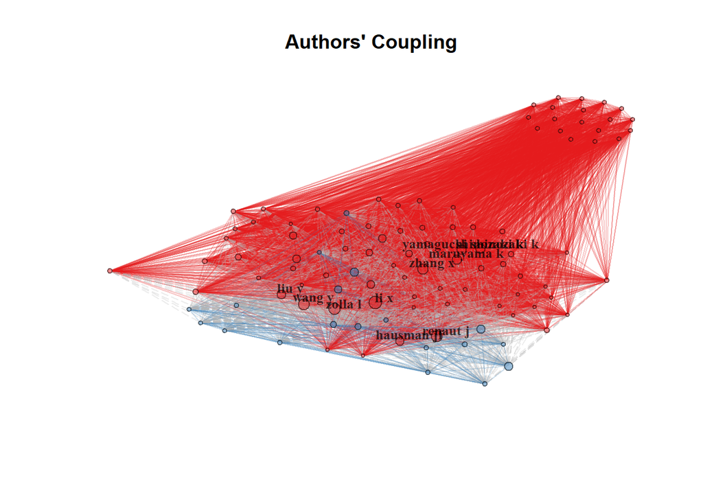

```r
options(width = 60)
NetMatrix <- biblioNetwork(M, analysis = "coupling", network = "authors", sep = ";")
options(width = 60)
net=networkPlot(NetMatrix,  normalize = "salton", weighted=NULL, n = 100, Title = "Authors' Coupling", type = "fruchterman", size=5,size.cex=T,remove.multiple=TRUE,labelsize=0.8, label.n=10,label.cex=F)
```

Co-citações bibliográficas Redes de co-citação de referências clássicas

```r
options(width = 60)
NetMatrix <- biblioNetwork(M, analysis = "co-citation", network = "references", sep = ".  ")
```

Colaboração bibliográfica

```r
options(width = 60)
NetMatrix <- biblioNetwork(M, analysis = "collaboration", network = "authors", sep = ";")
```

Redes de colaboração entre países

```r
options(width = 60)
NetMatrix <- biblioNetwork(M, analysis = "collaboration", network = "countries", sep = ";")
```

Análise descritiva das características de gráficos de rede Um exemplo de redes de co-ocorrência clássica

```r
options(width = 60)
NetMatrix <- biblioNetwork(M, analysis = "co-occurrences", network = "keywords", sep = ";")
options(width = 60)
netstat <- networkStat(NetMatrix)
```

Verificando os nomes da rede

```r
options(width = 60)
names(netstat$network)
```

```
##  [1] "networkSize"             "networkDensity"
##  [3] "networkTransitivity"     "networkDiameter"
##  [5] "networkDegreeDist"       "networkCentrDegree"
##  [7] "networkCentrCloseness"   "networkCentrEigen"
##  [9] "networkCentrbetweenness" "NetworkAverPathLeng"
```

```r
options(width = 60)
names(netstat$vertex)
```

Resumo da rede

```r
options(width = 60)
summary(netstat, k=10)
```

```
##
##
## Main statistics about the network
##
##  Size                                  1397
##  Density                               0.014
##  Transitivity                          0.168
##  Diameter                              4
##  Degree Centralization                 0.325
##  Average path length                   2.524
##
```

Redes de visualização bibliográfica Colaboração científica dos países Criação de uma rede de colaboração entre países

```r
options(width = 60)
M <- metaTagExtraction(M, Field = "AU_CO", sep = ";")
options(width = 60)
NetMatrix <- biblioNetwork(M, analysis = "collaboration", network = "countries", sep = ";")
```

Gráfico da rede

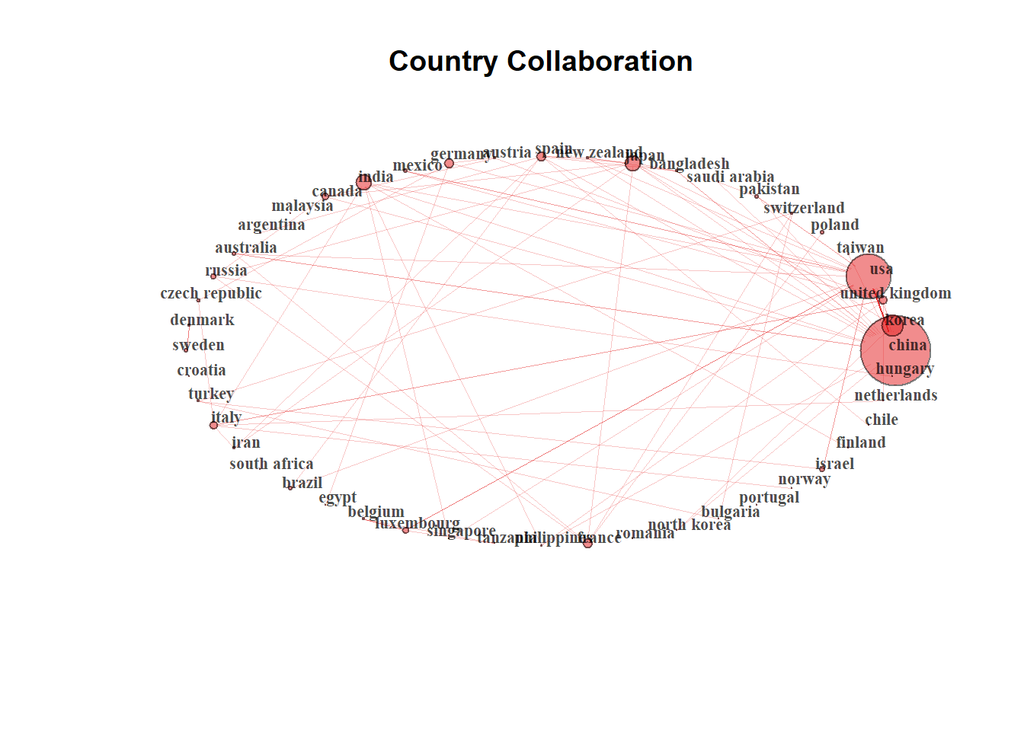

```r
options(width = 60)
net=networkPlot(NetMatrix, n = dim(NetMatrix)[1], Title = "Country Collaboration",           type = "circle", size=T, remove.multiple=FALSE, labelsize=0.7,cluster="none")
```

Redes de co-citação Criação de uma rede de co-citação

```r
options(width = 60)
NetMatrix <- biblioNetwork(M, analysis = "co-citation", network = "references", sep = ";")
```

Gráfico da rede

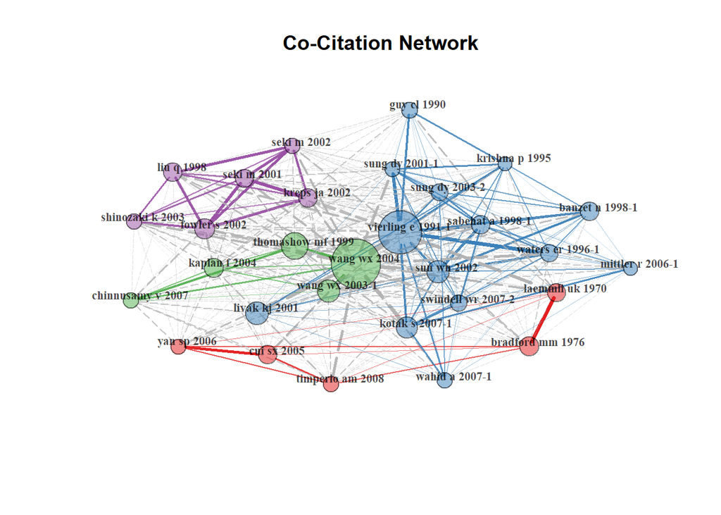

```r
options(width = 60)
net=networkPlot(NetMatrix, n = 30, Title = "Co-Citation Network", type = "fruchterman", size=T, remove.multiple=FALSE, labelsize=0.7,edgesize = 5)
```

Criação de rede de co-ocorrência de palavras-chave

```r
options(width = 60)
NetMatrix <- biblioNetwork(M, analysis = "co-occurrences", network = "keywords", sep = ";")
```

Gráfico da rede

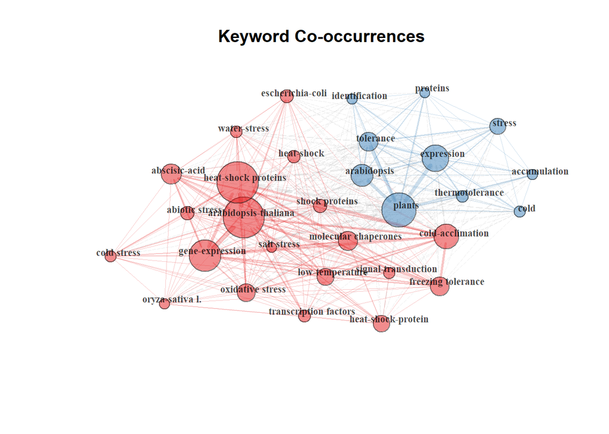

```r
options(width = 60)
net=networkPlot(NetMatrix, normalize="association", weighted=T, n = 30, Title = "Keyword Co-occurrences", type = "fruchterman", size=T,edgesize = 5,labelsize=0.7)
```

Análise de *co-word*: A estrutura conceitual de um campo Estrutura conceitual usando palavras-chave (método=“CA”)

```r
options(width = 60)
CS <- conceptualStructure(M,field="ID", method="CA", minDegree=4, k.max=8, stemming=FALSE, labelsize=10, documents=10)
```

[figure not shown]

[figure not shown]

[figure not shown]

[figure not shown]

Redes de citação histórica direta Criação de uma rede de citação histórica

```r
options(width = 60)
histResults <- histNetwork(M, min.citations = 10, sep = ";")
```

```
## Articles analysed   100
## Articles analysed   200
## Articles analysed   232
```

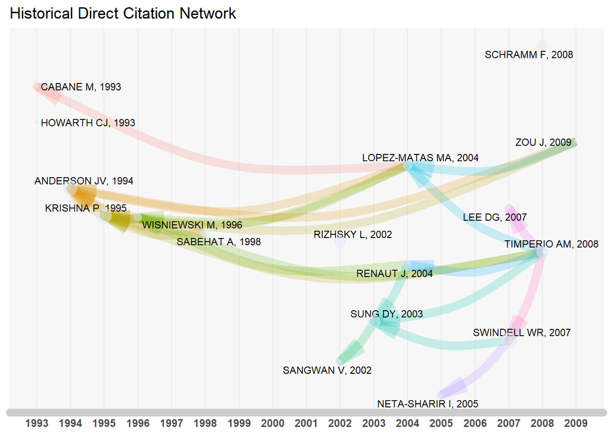

```
##
##  Legend
##
##                                          Paper
## 1993 - 4          HOWARTH CJ, 1993, NEW PHYTOL
## 1993 - 6                CABANE M, 1993, PLANTA
## 1994 - 12     ANDERSON JV, 1994, PLANT PHYSIOL
## 1995 - 17       KRISHNA P, 1995, PLANT PHYSIOL
## 1996 - 22    WISNIEWSKI M, 1996, PHYSIOL PLANT
## 1998 - 29       SABEHAT A, 1998, PHYSIOL PLANT
## 2002 - 53       RIZHSKY L, 2002, PLANT PHYSIOL
## 2002 - 56             SANGWAN V, 2002, PLANT J
## 2003 - 67      SUNG DY, 2003, TRENDS PLANT SCI
## 2004 - 72  LOPEZ-MATAS MA, 2004, PLANT PHYSIOL
## 2004 - 73           RENAUT J, 2004, PLANT BIOL
```

[output cut: 24 more lines]

```r
options(width = 60)
net <- histPlot(histResults, n=15, size = 20, labelsize=10, size.cex=TRUE, arrowsize = 0.5, color = TRUE)
```